# Анализ А/B теста

## Цели проекта

- провести оценку результатов A/B-теста;
- оценить корректность проведения теста;
- проанализировать результаты теста.

## Техническое задание

- название теста: recommender_system_test;
- группы: А (контрольная), B (новая платёжная воронка);
- дата запуска: 2020-12-07;
- дата остановки набора новых пользователей: 2020-12-21;
- дата остановки: 2021-01-04;
- аудитория: 15% новых пользователей из региона EU;
- назначение теста: тестирование изменений, связанных с внедрением улучшенной рекомендательной системы;
- ожидаемое количество участников теста: 6000.
- ожидаемый эффект: за 14 дней с момента регистрации в системе пользователи покажут улучшение каждой метрики не менее, чем на 10%:
- конверсии в просмотр карточек товаров — событие product_page
- просмотры корзины — product_cart
- покупки — purchase.

Загрузить данные теста, проверить корректность его проведения и проанализировать полученные результаты.

## Выводы

переход к выводам

## Оглавление

1. Изучение данных
1. Оценка корректности проведения теста

   2.1 Время проведения теста

   2.2 Аудитория теста

   2.3 Добавление датафрейма с событиями
1. Исследовательский анализ данных

   3.1 Количество событий на пользователя

   3.2 Распределение событий по дням

   3.3 Изменение конверсии в воронке в выборках на разных этапах
1. Оценка результатов A/B-тестирования
1. Проверка статистических гипотез
1. Общий вывод

## Изучение данных

```python
#импорт библиотек
import pandas as pd
import numpy as np
import matplotlib.pyplot as plt
from datetime import datetime, timedelta
import datetime as dt
from plotly import graph_objects as go
import plotly.express as px
from scipy import stats as st
import seaborn as sns
import matplotlib.dates as mdates
import math as mth

sns.set()
```

Загрузка данных

```python
#календарь маркетинговых событий на 2020 год
marketing = pd.read_csv(r'C:\Users\User\My Jupyter Projects\Выпускной\ABtest\ab_project_marketing_events.csv')
#все пользователи, зарегистрировавшиеся в интернет-магазине в период с 7 по 21 декабря 2020 года;
users = pd.read_csv(r'C:\Users\User\My Jupyter Projects\Выпускной\ABtest\final_ab_new_users.csv')
#все события новых пользователей в период с 7 декабря 2020 по 4 января 2021 года;
events = pd.read_csv(r'C:\Users\User\My Jupyter Projects\Выпускной\ABtest\final_ab_events.csv')
#таблица участников тестов.
ab_part = pd.read_csv(r'C:\Users\User\My Jupyter Projects\Выпускной\ABtest\final_ab_participants.csv')
```

### Календарь маркетинговых событий

```python
#просмотр информации
for i in [marketing]:
    display(i.info())
    display(i.head())
    display(i.duplicated().sum())
    display(i.isna().sum())
```

```
<class 'pandas.core.frame.DataFrame'>
RangeIndex: 14 entries, 0 to 13
Data columns (total 4 columns):
 #   Column     Non-Null Count  Dtype
---  ------     --------------  -----
 0   name       14 non-null     object
 1   regions    14 non-null     object
 2   start_dt   14 non-null     object
 3   finish_dt  14 non-null     object
dtypes: object(4)
memory usage: 576.0+ bytes
```

```
None
```

|  | name | regions | start_dt | finish_dt |
| --- | --- | --- | --- | --- |
| 0 | Christmas&New Year Promo | EU, N.America | 2020-12-25 | 2021-01-03 |
| 1 | St. Valentine's Day Giveaway | EU, CIS, APAC, N.America | 2020-02-14 | 2020-02-16 |
| 2 | St. Patric's Day Promo | EU, N.America | 2020-03-17 | 2020-03-19 |
| 3 | Easter Promo | EU, CIS, APAC, N.America | 2020-04-12 | 2020-04-19 |
| 4 | 4th of July Promo | N.America | 2020-07-04 | 2020-07-11 |

```
0
```

```
name         0
regions      0
start_dt     0
finish_dt    0
dtype: int64
```

В файле 14 строк и 4 столбца. Согласно документации, описание признаков следующее:

- name — название маркетингового события;
- regions — регионы, в которых будет проводиться рекламная кампания;
- start_dt — дата начала кампании;
- finish_dt — дата завершения кампании.

Дубликаты и пропуски отсутствуют.

Признакам start_dt и finish_dt необходимо преобразование типа данных.

```python
#преобразование типов
marketing['start_dt'] = pd.to_datetime(marketing['start_dt'])
marketing['finish_dt'] = pd.to_datetime(marketing['finish_dt'])
```

```python
#проверка периода
display(marketing.start_dt.min())
display(marketing.start_dt.max())
```

```
Timestamp('2020-01-25 00:00:00')
```

```
Timestamp('2020-12-30 00:00:00')
```

Данные представлены с 25 января 2020 года по 30 декабря 2020 года.

### Все пользователи

Все пользователи, зарегистрировавшиеся в интернет-магазине в период с 7 по 21 декабря 2020 года.

```python
#просмотр информации
for i in [users]:
    display(i.info())
    display(i.head())
    display(i.duplicated().sum())
    display(i.isna().sum())
```

```
<class 'pandas.core.frame.DataFrame'>
RangeIndex: 61733 entries, 0 to 61732
Data columns (total 4 columns):
 #   Column      Non-Null Count  Dtype
---  ------      --------------  -----
 0   user_id     61733 non-null  object
 1   first_date  61733 non-null  object
 2   region      61733 non-null  object
 3   device      61733 non-null  object
dtypes: object(4)
memory usage: 1.9+ MB
```

```
None
```

|  | user_id | first_date | region | device |
| --- | --- | --- | --- | --- |
| 0 | D72A72121175D8BE | 2020-12-07 | EU | PC |
| 1 | F1C668619DFE6E65 | 2020-12-07 | N.America | Android |
| 2 | 2E1BF1D4C37EA01F | 2020-12-07 | EU | PC |
| 3 | 50734A22C0C63768 | 2020-12-07 | EU | iPhone |
| 4 | E1BDDCE0DAFA2679 | 2020-12-07 | N.America | iPhone |

```
0
```

```
user_id       0
first_date    0
region        0
device        0
dtype: int64
```

В данных 61733 строки в 4 столбцах. Согласно документации, описание признаков следующее:

- user_id — идентификатор пользователя;
- first_date — дата регистрации;
- region — регион пользователя;
- device — устройство, с которого происходила регистрация.

Дубликаты и пропуски отсутствуют.

Признаку first_date требуется преобразование типа.

```python
#преобразование типов
users['first_date'] = pd.to_datetime(users['first_date'])
```

```python
#проверка периода
display(users.first_date.min())
display(users.first_date.max())
```

```
Timestamp('2020-12-07 00:00:00')
```

```
Timestamp('2020-12-23 00:00:00')
```

Данные представлены с 7го декабря 2020 года по 23 декабря 2020 года. Согласно ТЗ, данные должны быть ораничены 21м декабря 2020 года.

```python
#срез данных
users = users[users['first_date'] <= '2020-12-21 00:00:00']
users.head()
```

|  | user_id | first_date | region | device |
| --- | --- | --- | --- | --- |
| 0 | D72A72121175D8BE | 2020-12-07 | EU | PC |
| 1 | F1C668619DFE6E65 | 2020-12-07 | N.America | Android |
| 2 | 2E1BF1D4C37EA01F | 2020-12-07 | EU | PC |
| 3 | 50734A22C0C63768 | 2020-12-07 | EU | iPhone |
| 4 | E1BDDCE0DAFA2679 | 2020-12-07 | N.America | iPhone |

```python
users.region.value_counts()
```

```
EU           42340
N.America     8347
CIS           2900
APAC          2883
Name: region, dtype: int64
```

```python
users.device.value_counts()
```

```
Android    25161
PC         14310
iPhone     11477
Mac         5522
Name: device, dtype: int64
```

### События новых пользователей

Все события новых пользователей в период с 7 декабря 2020 по 4 января 2021 года

```python
#просмотр информации
for i in [events]:
    display(i.info())
    display(i.head())
    display(i.duplicated().sum())
    display(i.isna().sum())
```

```
<class 'pandas.core.frame.DataFrame'>
RangeIndex: 440317 entries, 0 to 440316
Data columns (total 4 columns):
 #   Column      Non-Null Count   Dtype
---  ------      --------------   -----
 0   user_id     440317 non-null  object
 1   event_dt    440317 non-null  object
 2   event_name  440317 non-null  object
 3   details     62740 non-null   float64
dtypes: float64(1), object(3)
memory usage: 13.4+ MB
```

```
None
```

|  | user_id | event_dt | event_name | details |
| --- | --- | --- | --- | --- |
| 0 | E1BDDCE0DAFA2679 | 2020-12-07 20:22:03 | purchase | 99.99 |
| 1 | 7B6452F081F49504 | 2020-12-07 09:22:53 | purchase | 9.99 |
| 2 | 9CD9F34546DF254C | 2020-12-07 12:59:29 | purchase | 4.99 |
| 3 | 96F27A054B191457 | 2020-12-07 04:02:40 | purchase | 4.99 |
| 4 | 1FD7660FDF94CA1F | 2020-12-07 10:15:09 | purchase | 4.99 |

```
0
```

```
user_id            0
event_dt           0
event_name         0
details       377577
dtype: int64
```

В данных представлено 440317 строк в 4х столбцах. Согласно документации, описание признаков следующее:

- user_id — идентификатор пользователя;
- event_dt — дата и время события;
- event_name — тип события;
- details — дополнительные данные о событии. Например, для покупок, purchase, в этом поле хранится стоимость покупки в долларах.

Признаку event_dt требуется преобразование типа.

Дубликаты в данных отсутствуют.

В признаке details 377577 пропусков.

```python
#доля пропусков в признаке details
round(events['details'].isna().sum() / len(events), 2)
```

```
0.86
```

```python
#атрибуты в признаке event_name
events.event_name.value_counts()
```

```
login           189552
product_page    125563
purchase         62740
product_cart     62462
Name: event_name, dtype: int64
```

- purchase;
- product_cart;
- product_page;
- login;

```python
#значения в признаке details
events.details.value_counts()
```

```
4.99      46362
9.99       9530
99.99      5631
499.99     1217
Name: details, dtype: int64
```

В признаке details находятся стоимоссть покупки для атрибута purchase, для остальных - NaN. Заменим NaN на "1".

```python
#замена NaN в признаке details
events['details'] = events.details.fillna(1)
```

```python
#проверка
events.isna().sum()
```

```
user_id       0
event_dt      0
event_name    0
details       0
dtype: int64
```

Пропущенные значения заменены

```python
#преобразование типов
events['event_dt'] = pd.to_datetime(events['event_dt'])
```

```python
#проверка периода
display(events.event_dt.min())
display(events.event_dt.max())
```

```
Timestamp('2020-12-07 00:00:33')
```

```
Timestamp('2020-12-30 23:36:33')
```

Временной период представлен от 07 декабря 2020 по 30 декабря 2020 года. Однако в ТЗ сказано, что события новых пользователей должны быть в диапазоне от 7 декабря 2020 по 4 января 2021 года, следовательно либо данные представлены не полностью, либо тест остановлен раньше срока.

### Участники теста

```python
#просмотр информации
for i in [ab_part]:
    display(i.info())
    display(i.head())
    display(i.duplicated().sum())
    display(i.isna().sum())
```

```
<class 'pandas.core.frame.DataFrame'>
RangeIndex: 18268 entries, 0 to 18267
Data columns (total 3 columns):
 #   Column   Non-Null Count  Dtype
---  ------   --------------  -----
 0   user_id  18268 non-null  object
 1   group    18268 non-null  object
 2   ab_test  18268 non-null  object
dtypes: object(3)
memory usage: 428.3+ KB
```

```
None
```

|  | user_id | group | ab_test |
| --- | --- | --- | --- |
| 0 | D1ABA3E2887B6A73 | A | recommender_system_test |
| 1 | A7A3664BD6242119 | A | recommender_system_test |
| 2 | DABC14FDDFADD29E | A | recommender_system_test |
| 3 | 04988C5DF189632E | A | recommender_system_test |
| 4 | 482F14783456D21B | B | recommender_system_test |

```
0
```

```
user_id    0
group      0
ab_test    0
dtype: int64
```

В данных представлено 18268 строк в 3х столбцах. Согласно документации, описание признаков следующее:

- user_id — идентификатор пользователя;
- ab_test — название теста;
- group — группа пользователя.

Дубликаты в данных отсутствуют.

```python
#уникальные значения признака group
ab_part.group.value_counts()
```

```
A    9655
B    8613
Name: group, dtype: int64
```

```python
#уникальные значения признака ab_test
ab_part.ab_test.value_counts()
```

```
interface_eu_test          11567
recommender_system_test     6701
Name: ab_test, dtype: int64
```

Группы представлены литерами А и В. В признаке ab_test значения 2х тестов, пересечения пользователей в которых будут проверены на следующей стадии.

### Вывод

Данные представляют из себя 4 датафрейма:

- календарь маркетинговых событий на 2020 год;
- все пользователи, зарегистрировавшиеся в интернет-магазине в период с 7 по 21 декабря 2020 года;
- все события новых пользователей в период с 7 декабря 2020 по 4 января 2021 года;
- таблица участников тестов

Для календаря маркетинговых событий, датафрейма всех пользователей, датафрейма событий новых пользователей были преобразованы типы данных в столбцах с датами. Для датафрейма всех пользователей был произведен срез данных согласно условию ТЗ об ограничении данных 21м декабря 2020 года.

Дубликаты в данных отсутствуют.

В датафрейме о событиях новых пользователей в признаке details отмечается большое количество пропусков. В этом признаке хранится стоимость, в случает если событие == покупка. А остальных случаях - значение NaN было заменено на "1".

Данные в событиях новых пользователей ограничиваются 30м декабря 2020 года, однако в ТЗ сказано, что диапазон должен быть в диапазоне от 7 декабря 2020 по 4 января 2021 года, следовательно либо данные представлены не полностью, либо тест остановлен раньше срока.

Также данные в датафрейме всех пользователей, по ТЗ должны быть ограничены 21м декабря 2020 года, однако фактически данные были представлены по 23 декабря 2020 года. Был произведен срез данных до момента, указанного в ТЗ.

переход к оглавлению

## Оценка корректности проведения теста

### Время проведения теста

```python
#события в датафрейме событий
display(events.event_dt.min())
display(events.event_dt.max())
```

```
Timestamp('2020-12-07 00:00:33')
```

```
Timestamp('2020-12-30 23:36:33')
```

```python
#акции в датафрейме акций
display(marketing.start_dt.min())
display(marketing.start_dt.max())
```

```
Timestamp('2020-01-25 00:00:00')
```

```
Timestamp('2020-12-30 00:00:00')
```

Крайние даты в датафреймах пересекаются, следовательно некоторые акции проходили в момент проведения тестов.

```python
marketing[marketing.start_dt >= '2020-12-07']
```

|  | name | regions | start_dt | finish_dt |
| --- | --- | --- | --- | --- |
| 0 | Christmas&New Year Promo | EU, N.America | 2020-12-25 | 2021-01-03 |
| 10 | CIS New Year Gift Lottery | CIS | 2020-12-30 | 2021-01-07 |

переход к оглавлению

### Аудитория теста

Удостовериться, что нет пересечений с конкурирующим тестом и нет пользователей, участвующих в двух группах теста одновременно. Проверить равномерность распределения пользователей по тестовым группам и правильность их формирования.

```python
#датафрейм
ab_part.head()
```

|  | user_id | group | ab_test |
| --- | --- | --- | --- |
| 0 | D1ABA3E2887B6A73 | A | recommender_system_test |
| 1 | A7A3664BD6242119 | A | recommender_system_test |
| 2 | DABC14FDDFADD29E | A | recommender_system_test |
| 3 | 04988C5DF189632E | A | recommender_system_test |
| 4 | 482F14783456D21B | B | recommender_system_test |

```python
#распределение пользователей
ab_part.groupby('ab_test').agg({'user_id':'nunique', 'group':'nunique'}).reset_index()
```

|  | ab_test | user_id | group |
| --- | --- | --- | --- |
| 0 | interface_eu_test | 11567 | 2 |
| 1 | recommender_system_test | 6701 | 2 |

Количество уникальных пользователей, участвующих в тесте - recommender_system_test - 6701.

```python
#проверка пересечения пользователей в тестах
users_in_two = ab_part.groupby('user_id').agg({'ab_test': 'nunique'}).query('ab_test > 1')
users_in_two.count()
```

```
ab_test    1602
dtype: int64
```

1602 пользователя имеют принадлежность к обоим тестам одновременно. Для изоляции групп и получении более достоверных результатов, этих пользователей необходимо удалить.

```python
#удаление пользователей принадлежащих двум тестам
ab_part = ab_part.query('user_id not in @users_in_two.index')
```

Пользователи, которые пересекались в двух тестах удалены. Для дальнейших исследований необходим только один тест - recommender_system_test, следовательно данные о втором тесте можно отсечь.

```python
#проверка на принадлежность одного пользователя двум группам
ab_part.groupby('user_id').agg({'group': 'nunique'}).query('group > 1').count()
```

```
group    0
dtype: int64
```

```python
#фильтрация по атрбуту признака ab_test
ab_part_filtered = ab_part.query('ab_test == "recommender_system_test"')
ab_part_filtered.head()
```

|  | user_id | group | ab_test |
| --- | --- | --- | --- |
| 0 | D1ABA3E2887B6A73 | A | recommender_system_test |
| 1 | A7A3664BD6242119 | A | recommender_system_test |
| 4 | 482F14783456D21B | B | recommender_system_test |
| 5 | 4FF2998A348C484F | A | recommender_system_test |
| 6 | 7473E0943673C09E | A | recommender_system_test |

```python
#группировка данных
test = ab_part_filtered.groupby('group').agg({'user_id':'nunique'}).reset_index()
display(test.sum())
```

```
group        AB
user_id    5099
dtype: object
```

Данных меньше, чем заявлено в ТЗ (Ожидаемое количество участников теста: 6000) - 5099.

```python
#распределение пользователей по регионам
users.region.value_counts()
```

```
EU           42340
N.America     8347
CIS           2900
APAC          2883
Name: region, dtype: int64
```

Также, согласно коду выше, пользователи могут быть не только из EU.

```python
#объединение датафрейма всех пользователей с датафреймом учасников теста
merged_users = pd.merge(ab_part_filtered, users, on = 'user_id')
merged_users.head()
```

|  | user_id | group | ab_test | first_date | region | device |
| --- | --- | --- | --- | --- | --- | --- |
| 0 | D1ABA3E2887B6A73 | A | recommender_system_test | 2020-12-07 | EU | PC |
| 1 | A7A3664BD6242119 | A | recommender_system_test | 2020-12-20 | EU | iPhone |
| 2 | 482F14783456D21B | B | recommender_system_test | 2020-12-14 | EU | PC |
| 3 | 4FF2998A348C484F | A | recommender_system_test | 2020-12-20 | EU | Mac |
| 4 | 7473E0943673C09E | A | recommender_system_test | 2020-12-16 | EU | iPhone |

```python
#распределение потзователей по регионам
merged_users.region.value_counts()
```

```
EU           4749
N.America     223
APAC           72
CIS            55
Name: region, dtype: int64
```

```python
#расчёт доли новых пользователей
merged_users.query('region == "EU"')['user_id'].nunique() / users.query('region == "EU"')['user_id'].nunique() * 100
```

```
11.216343882853094
```

В результате получаем 11,2%

```python
#срез данных по региону
merged_users = merged_users.query('region == "EU"')
merged_users.head()
```

|  | user_id | group | ab_test | first_date | region | device |
| --- | --- | --- | --- | --- | --- | --- |
| 0 | D1ABA3E2887B6A73 | A | recommender_system_test | 2020-12-07 | EU | PC |
| 1 | A7A3664BD6242119 | A | recommender_system_test | 2020-12-20 | EU | iPhone |
| 2 | 482F14783456D21B | B | recommender_system_test | 2020-12-14 | EU | PC |
| 3 | 4FF2998A348C484F | A | recommender_system_test | 2020-12-20 | EU | Mac |
| 4 | 7473E0943673C09E | A | recommender_system_test | 2020-12-16 | EU | iPhone |

```python
#группировка данных
test = merged_users.groupby('group')['user_id'].nunique().to_frame().reset_index()
test['perc'] = round(test.user_id / test.user_id.sum(), 2)
test
```

|  | group | user_id | perc |
| --- | --- | --- | --- |
| 0 | A | 2713 | 0.57 |
| 1 | B | 2036 | 0.43 |

Распределение неравномерное, в группе A - 57%, B - 43%.

переход к оглавлению

### Добавление датафрейма с событиями

```python
#добавление датафрейма с событиями
merged_events = merged_users.merge(events, on='user_id')
merged_events.head()
```

|  | user_id | group | ab_test | first_date | region | device | event_dt | event_name | details |
| --- | --- | --- | --- | --- | --- | --- | --- | --- | --- |
| 0 | D1ABA3E2887B6A73 | A | recommender_system_test | 2020-12-07 | EU | PC | 2020-12-07 14:43:27 | purchase | 99.99 |
| 1 | D1ABA3E2887B6A73 | A | recommender_system_test | 2020-12-07 | EU | PC | 2020-12-25 00:04:56 | purchase | 4.99 |
| 2 | D1ABA3E2887B6A73 | A | recommender_system_test | 2020-12-07 | EU | PC | 2020-12-07 14:43:29 | product_cart | 1.00 |
| 3 | D1ABA3E2887B6A73 | A | recommender_system_test | 2020-12-07 | EU | PC | 2020-12-25 00:04:57 | product_cart | 1.00 |
| 4 | D1ABA3E2887B6A73 | A | recommender_system_test | 2020-12-07 | EU | PC | 2020-12-07 14:43:27 | product_page | 1.00 |

По ТЗ, в данных должны остаться пользователи, время жизни событий которых не превышает 14 дней.

```python
#создание признака времени жизни
merged_events['lifetime'] = merged_events.event_dt - merged_events.first_date
#формат даты
merged_events['lifetime'] = merged_events['lifetime'].dt.days
merged_events.head()
```

|  | user_id | group | ab_test | first_date | region | device | event_dt | event_name | details | lifetime |
| --- | --- | --- | --- | --- | --- | --- | --- | --- | --- | --- |
| 0 | D1ABA3E2887B6A73 | A | recommender_system_test | 2020-12-07 | EU | PC | 2020-12-07 14:43:27 | purchase | 99.99 | 0 |
| 1 | D1ABA3E2887B6A73 | A | recommender_system_test | 2020-12-07 | EU | PC | 2020-12-25 00:04:56 | purchase | 4.99 | 18 |
| 2 | D1ABA3E2887B6A73 | A | recommender_system_test | 2020-12-07 | EU | PC | 2020-12-07 14:43:29 | product_cart | 1.00 | 0 |
| 3 | D1ABA3E2887B6A73 | A | recommender_system_test | 2020-12-07 | EU | PC | 2020-12-25 00:04:57 | product_cart | 1.00 | 18 |
| 4 | D1ABA3E2887B6A73 | A | recommender_system_test | 2020-12-07 | EU | PC | 2020-12-07 14:43:27 | product_page | 1.00 | 0 |

```python
#срез данных lifetime которых выходит за границы по ТЗ
merged_events = merged_events.query('lifetime <= 14')
merged_events.head()
```

|  | user_id | group | ab_test | first_date | region | device | event_dt | event_name | details | lifetime |
| --- | --- | --- | --- | --- | --- | --- | --- | --- | --- | --- |
| 0 | D1ABA3E2887B6A73 | A | recommender_system_test | 2020-12-07 | EU | PC | 2020-12-07 14:43:27 | purchase | 99.99 | 0 |
| 2 | D1ABA3E2887B6A73 | A | recommender_system_test | 2020-12-07 | EU | PC | 2020-12-07 14:43:29 | product_cart | 1.00 | 0 |
| 4 | D1ABA3E2887B6A73 | A | recommender_system_test | 2020-12-07 | EU | PC | 2020-12-07 14:43:27 | product_page | 1.00 | 0 |
| 6 | D1ABA3E2887B6A73 | A | recommender_system_test | 2020-12-07 | EU | PC | 2020-12-07 14:43:27 | login | 1.00 | 0 |
| 8 | A7A3664BD6242119 | A | recommender_system_test | 2020-12-20 | EU | iPhone | 2020-12-20 15:46:06 | product_page | 1.00 | 0 |

### Вывод

Была произведена оценка корректности теста путем сравнения имеющихся данных с тех.заданием. В момент проведения теста проходила промо акция, пользователи во время проведения акций ведут себя иначе, соответственно этот факт прямо указывает на не лигитимность результотов тестирования.

Распределение пользователей по группам тестирования - неравномерное, в группе А - 57%, в В - 43%.

Также в данных есть сведения о другом тесте, 1602 пользователей, имеют принадлежность к обоим тестам одновременно.

Процент новых пользователей региона EU - не соответствует ТЗ - 11,2%

переход к оглавлению

## Исследовательский анализ данных

### Количество событий на пользователя

```python
#датафрейм
merged_events.head()
```

|  | user_id | group | ab_test | first_date | region | device | event_dt | event_name | details | lifetime |
| --- | --- | --- | --- | --- | --- | --- | --- | --- | --- | --- |
| 0 | D1ABA3E2887B6A73 | A | recommender_system_test | 2020-12-07 | EU | PC | 2020-12-07 14:43:27 | purchase | 99.99 | 0 |
| 2 | D1ABA3E2887B6A73 | A | recommender_system_test | 2020-12-07 | EU | PC | 2020-12-07 14:43:29 | product_cart | 1.00 | 0 |
| 4 | D1ABA3E2887B6A73 | A | recommender_system_test | 2020-12-07 | EU | PC | 2020-12-07 14:43:27 | product_page | 1.00 | 0 |
| 6 | D1ABA3E2887B6A73 | A | recommender_system_test | 2020-12-07 | EU | PC | 2020-12-07 14:43:27 | login | 1.00 | 0 |
| 8 | A7A3664BD6242119 | A | recommender_system_test | 2020-12-20 | EU | iPhone | 2020-12-20 15:46:06 | product_page | 1.00 | 0 |

```python
#разделение df согласно групп
gr_a = merged_events.query('group == "A"')
gr_b = merged_events.query('group == "B"')
#количество событий на пользователя
display(round(gr_a.groupby('user_id')['event_name'].count().mean(), 2))
display(round(gr_b.groupby('user_id')['event_name'].count().mean(), 2))
```

```
6.96
```

```
5.49
```

Среднее количество событий для пользователей из группы А - 6,96, В - 5,49.

переход к оглавлению

### Распределение событий по дням

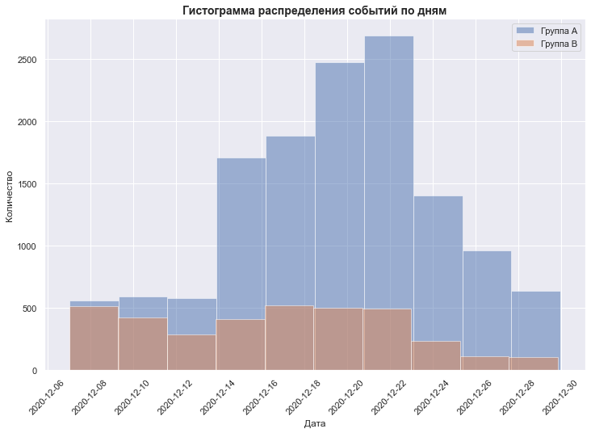

```python
#визуализация
fig, ax = plt.subplots(figsize=(12, 8))
plt.hist(merged_events.query('group == "A"')['event_dt'], bins=10, alpha=0.5, label='Группа А')
plt.hist(merged_events.query('group == "B"')['event_dt'], bins=10, alpha=0.5, label='Группа В')
plt.xlabel('Дата')
plt.ylabel('Количество')
plt.title('Гистограмма распределения событий по дням', fontweight='bold', fontsize=14)
plt.legend()
plt.xticks(rotation=45)
locator = mdates.DayLocator(interval=2)
plt.gca().xaxis.set_major_locator(locator)
plt.grid(True)
plt.show()
```

Группа B менее активна относительно группы А. У группы А наблюдается большой рост числа событий с 14го по 23 декабря.

переход к оглавлению

### Изменение конверсии в воронке в выборках на разных этапах

```python
#общее количество по группам
temp = merged_events.groupby('group')['user_id'].nunique()
temp
```

```
group
A    1939
B     655
Name: user_id, dtype: int64
```

```python
#сводная таблица
convers = (merged_events.pivot_table(
    index='event_name',
    columns='group',
    values='user_id',
    aggfunc='nunique')
    .sort_values(by='A', ascending=False)
    .reindex(['login', 'product_page', 'product_cart', 'purchase'])
    .reset_index(drop=False)
    )
convers['perc_A'] = (convers['A'] / temp['A'] * 100).round(1)
convers['perc_B'] = (convers['B'] / temp['B'] * 100).round(1)

convers
```

| group | event_name | A | B | perc_A | perc_B |
| --- | --- | --- | --- | --- | --- |
| 0 | login | 1939 | 654 | 100.0 | 99.8 |
| 1 | product_page | 1265 | 367 | 65.2 | 56.0 |
| 2 | product_cart | 589 | 184 | 30.4 | 28.1 |
| 3 | purchase | 613 | 191 | 31.6 | 29.2 |

```python
#визуализация
fig = go.Figure()

fig.add_trace(go.Funnel(
    name = 'A',
    y = convers['event_name'],
    x = convers['A'],
    textinfo = "value+percent initial+percent previous"))

fig.add_trace(go.Funnel(
    name = 'B',
    y = convers['event_name'],
    x = convers['B'],
    textinfo = "value+percent initial+percent previous"))

fig.show()
```

[interactive chart not shown]

переход к оглавлению

### Особенности данных которые следует учесть, прежде чем приступать к A/B-тестированию?

- Разное количество пользователей в группах;
- Разная интенсивность событий у групп;
- Сбор данных закончен раньше срока;
- Общее количество пользователей, после срезов данных - менее 6000, что несоответствует ТЗ;

## Оценка результатов A/B-тестирования

Тест можно признать не корректным:

- Ранняя дата остановки теста;
- Неравномерное распределение пользователей в группах;
- Ожидаемый эффект в увеличение конверсии на 10% в группе B - не наблюдается.

переход к оглавлению

## Проверка статистических гипотез

Сформулируем гипотезы:

Первая нулевая гипотеза H0 - Статистически значимых различий в долях групп А и В нет.

Первая альтернативная гипотеза H1 - Статистически значимые различия в долях групп А и В есть.

```python
#датафрейм
convers
```

| group | event_name | A | B | perc_A | perc_B |
| --- | --- | --- | --- | --- | --- |
| 0 | login | 1939 | 654 | 100.0 | 99.8 |
| 1 | product_page | 1265 | 367 | 65.2 | 56.0 |
| 2 | product_cart | 589 | 184 | 30.4 | 28.1 |
| 3 | purchase | 613 | 191 | 31.6 | 29.2 |

Создание функции с 3 аргументами z_test(group1, group2, alpha_value): значения 1-ой группы, значения 2-ой группы и уровень статистической значимости alpha.

```python
def z_test(group1, group2, alpha_value):
    alpha = alpha_value
    event_name = convers['event_name']

    for i in range(1,len(group1)):

        successes = np.array([group1[i], group2[i]])
        trials = np.array([group1[0], group2[0]])

        # пропорция успехов в 1 группе
        p1 = successes[0] / trials[0]
        # пропорция успехов во 2 группе
        p2 = successes[1] / trials[1]


        # пропорция успехов в комбинированном датасете
        p_combined = (successes[0] + successes[1]) / (trials[0] + trials[1])
        # разница пропорций в датасетах
        difference = p1 - p2

        # считаем статистику в ст.отклонениях стандартного нормального распределения
        z_value = difference / mth.sqrt(p_combined * (1 - p_combined) * (1/trials[0] + 1/trials[1]))

        # задаем стандартное нормальное распределение (среднее 0, ст.отклонение 1)
        distr = st.norm(0, 1)
        p_value = (1 - distr.cdf(abs(z_value))) * 2

        # введем поправку Бонферрони, поделим альфа на число гипотез для всех проверок
        bonferroni_alpha = alpha / 3

        print('Для события "{}" '.format(event_name[i]), end='')
        print('(P-value =', p_value.round(3),'):')
        if (p_value < bonferroni_alpha):
            print('Отвергаем нулевую гипотезу о равенстве долей в группах')
        else:
            print('Не получилось отвергнуть нулевую гипотезу о равенстве долей в группах')

        print('')
```

```python
z_test(convers['A'], convers['B'], 0.05)
```

```
Для события "product_page" (P-value = 0.0 ):
Отвергаем нулевую гипотезу о равенстве долей в группах

Для события "product_cart" (P-value = 0.278 ):
Не получилось отвергнуть нулевую гипотезу о равенстве долей в группах

Для события "purchase" (P-value = 0.249 ):
Не получилось отвергнуть нулевую гипотезу о равенстве долей в группах
```

### Вывод

Между группами А и В различия статистически значимы на уровне значимости alpha=0.05 только для события product_page. Для событий product_cart и purchase в долях групп А и В - нет статистически значимой разницы.

переход к оглавлению

## Общий вывод

Среднее количество событий для пользователей:

- для группы А - 6,96
- для группы В - 5,49

Количество событий значительно различается между группами, так для группы А отмечается интенсивный рост числа событий с 14го по 23 декабря, группа В демонстрирует практически равномерное число событий на всем исследуемом отрезке времени, с тенденцией к спаду после 24 декабря.

Нет оснований считать проведенный тест корректным:

- Дата остановки 2020-12-30 вместо 2021-01-04;
- Общее количество пользователей, участвующих в тесте - 2594, в ТЗ - 6000;
- Ожидаемый эффект не достигнут;
- Во время проведения теста проходило маркетинговое событие.

переход к оглавлению